# Exercise 12 - Misc Text and Networks

Ionelia Buzatu

```r
library(quanteda, warn.conflicts = FALSE, quietly = TRUE)
```

1. **Using regular expressions**

   Regular expressions are very important concepts in text processing, as they offer tools for searching and matching text strings based on symbolic representations. For the dictionary and thesaurus features, we can define equivalency classes in terms of regular expressions. There is an excellent tutorial on regular expressions at http://www.regular-expressions.info.

   This provides an easy way to recover syntactic variations on specific words, without relying on a stemmer. For instance, we could query a regular expression on tax-related words, using:

   ```r
   kwic(data_corpus_inaugural, "tax", window = 2, valuetype = "regex")
   ```

   ```
   ##
   ##   [1805-Jefferson, 276]          our internal |    taxes    |
   ##   [1805-Jefferson, 322]           among these |    taxes    |
   ##   [1805-Jefferson, 438]                sees a | taxgatherer |
   ##     [1817-Monroe, 2830]                , that |    taxes    |
   ##     [1821-Monroe, 2896]            the direct |     tax     |
   ##     [1821-Monroe, 2992]            measure of |  taxation   |
   ##     [1821-Monroe, 3066]           or internal |    taxes    |
   ##     [1821-Monroe, 3136]          the internal |    taxes    |
   ##      [1825-Adams, 1478]             burden of |  taxation   |
   ##      [1825-Adams, 2345]          the internal |    taxes    |
   ##     [1833-Jackson, 781]       impoverished by |    taxes    |
   ##   [1837-VanBuren, 1439]              bear the |  taxation   |
   ##       [1845-Polk, 2725]                of the |    taxes    |
   ##       [1845-Polk, 2780]         Government to |     tax     |
   ##       [1845-Polk, 3004]           and collect |    taxes    |
   ##       [1845-Polk, 3227]                  . To |     tax     |
   ##       [1845-Polk, 3319]           millions by |   taxing    |
   ##       [1845-Polk, 3488]               of such |    taxes    |
   ##  [1885-Cleveland, 1291]        of unnecessary |  taxation   |
   ##  [1893-Cleveland, 1477]            of Federal |  taxation   |
   ##  [1893-Cleveland, 1673]     justification for |   taxing    |
   ##  [1893-Cleveland, 1704]                of the |   taxing    |
   ##   [1897-McKinley, 1207]             system of |  taxation   |
   ##   [1897-McKinley, 1245]          revenue from |    taxes    |
   ##   [1897-McKinley, 1270]             of direct |  taxation   |
   ##   [1897-McKinley, 1292]           of internal |  taxation   |
   ##   [1897-McKinley, 1307]             of tariff |  taxation   |
   ##   [1897-McKinley, 1324]           this tariff |  taxation   |
   ##    [1901-McKinley, 103]           has reduced |  taxation   |
   ##       [1909-Taft, 1039]             motive is |  taxation   |
   ##       [1909-Taft, 1152]              kinds of |  taxation   |
   ##       [1909-Taft, 1165] graduated inheritance |     tax     |
   ##       [1909-Taft, 1209]             burden of |  taxation   |
   ##       [1909-Taft, 1397]     another necessary |     tax     |
   ##       [1909-Taft, 2404]         of additional |  taxation   |
   ##      [1913-Wilson, 570]           of energies |  overtaxed  |
   ##     [1913-Wilson, 1024]         principles of |  taxation   |
   ##    [1921-Harding, 2006]                at war |  taxation   |
   ##    [1921-Harding, 2464]         for lightened |     tax     |
   ```

   [output cut: 79 more lines]

   ```
   ##  have contributed
   ##  have risen
   ##  system which
   ##  burden is
   ##  support the
   ##  burden.
   ##  and inflation
   ##  rates have
   ##  system,
   ##  , will
   ##  and spend
   ##  them into
   ##  , to
   ##  Code,
   ##  , on
   ```

   What is the result between that command, and the version `kwic(inaugCorpus, "tax")`?

   ```r
   kwic(data_corpus_inaugural, "tax", window = 2)
   ```

   ```
   ##
   ##    [1821-Monroe, 2896]            the direct | tax | and excise
   ##      [1845-Polk, 2780]         Government to | tax | one section
   ##      [1845-Polk, 3227]                  . To | tax | one branch
   ##      [1909-Taft, 1165] graduated inheritance | tax | as correct
   ##      [1909-Taft, 1397]     another necessary | tax | upon Government
   ##   [1921-Harding, 2464]         for lightened | tax | burdens,
   ##  [1925-Coolidge, 2839]          making their | tax | returns,
   ##  [1925-Coolidge, 3030]           solving our | tax | problem is
   ##  [1925-Coolidge, 3113]   only constitutional | tax | is the
   ##  [1925-Coolidge, 3116]                is the | tax | which ministers
   ##  [1925-Coolidge, 3242]          have further | tax | reduction,
   ##  [1925-Coolidge, 3265]             must have | tax | reform.
   ##     [1981-Reagan, 307]                  by a | tax | system which
   ##     [1981-Reagan, 325]                as our | tax | burden is
   ##    [1981-Reagan, 1753]          our punitive | tax | burden.
   ##     [1985-Reagan, 566]                 that. | Tax | rates have
   ##    [1985-Reagan, 1264]          simplify our | tax | system,
   ##    [1985-Reagan, 1624]              power to | tax | and spend
   ##    [1985-Reagan, 1646]             money and | tax | them into
   ##      [2013-Obama, 818]            revamp our | Tax | Code,
   ```

   **The second version returns only the word “tax” as a whole word, not “tax” as a regular expression, which would match to “taxes”, “stax”, “tiktax”, etc.**

   What if we on wanted to construct a regular expression to query only “valued” and “values” but not other variations of the lemma “value”?

   ```r
   kwic(data_corpus_inaugural, "^value[ds]$", window = 2, valuetype = "regex")
   ```

   ```
   ##
   ##        [1873-Grant, 806]       standard of | values | --
   ##       [1877-Hayes, 1860]    fluctuation of | values | , is
   ##    [1889-Harrison, 2911]         no nation | values | more highly
   ##    [1889-Harrison, 4691]             , and | valued | , we
   ##    [1933-Roosevelt, 197]           things. | Values | have shrunken
   ##    [1933-Roosevelt, 572]      apply social | values | more noble
   ##    [1933-Roosevelt, 693]             to be | valued | only by
   ##    [1933-Roosevelt, 928]         raise the | values | of agricultural
   ##   [1933-Roosevelt, 1929]    precious moral | values | ; with
   ##  [1953-Eisenhower, 2417]       people that | values | its privileges
   ##  [1957-Eisenhower, 1006] comprehending the | values | of freedom
   ##      [1965-Johnson, 183]       shaking old | values | , and
   ##      [1977-Carter, 1340]     most precious | values | . These
   ##      [1981-Reagan, 1472]           . Their | values | sustain our
   ##       [1985-Reagan, 666]          when our | values | of faith
   ##      [1985-Reagan, 1460]           and the | values | of faith
   ##      [1997-Clinton, 379]            to our | values | of free
   ##      [1997-Clinton, 724]           for our | values | and interests
   ##     [1997-Clinton, 1733]            of its | values | . A
   ##        [2001-Bush, 1015]           for the | values | that gave
   ##        [2001-Bush, 1290] responsibility is | valued | and expected
   ##        [2001-Bush, 1483]         bring the | values | of our
   ##       [2009-Obama, 2206]         But those | values | upon which
   ##       [2013-Obama, 1400]        uphold our | values | through strength
   ##       [2013-Obama, 1890]           , these | values | of life
   ##       [2013-Obama, 2243]      most ancient | values | and enduring
   ```

   Could we construct a “glob” pattern match for the same two words?

   ```r
   kwic(data_corpus_inaugural, "value?", window = 2)
   ```

   ```
   ##
   ##        [1873-Grant, 806]       standard of | values | --
   ##       [1877-Hayes, 1860]    fluctuation of | values | , is
   ##    [1889-Harrison, 2911]         no nation | values | more highly
   ##    [1889-Harrison, 4691]             , and | valued | , we
   ##    [1933-Roosevelt, 197]           things. | Values | have shrunken
   ##    [1933-Roosevelt, 572]      apply social | values | more noble
   ##    [1933-Roosevelt, 693]             to be | valued | only by
   ##    [1933-Roosevelt, 928]         raise the | values | of agricultural
   ##   [1933-Roosevelt, 1929]    precious moral | values | ; with
   ##  [1953-Eisenhower, 2417]       people that | values | its privileges
   ##  [1957-Eisenhower, 1006] comprehending the | values | of freedom
   ##      [1965-Johnson, 183]       shaking old | values | , and
   ##      [1977-Carter, 1340]     most precious | values | . These
   ##      [1981-Reagan, 1472]           . Their | values | sustain our
   ##       [1985-Reagan, 666]          when our | values | of faith
   ##      [1985-Reagan, 1460]           and the | values | of faith
   ##      [1997-Clinton, 379]            to our | values | of free
   ##      [1997-Clinton, 724]           for our | values | and interests
   ##     [1997-Clinton, 1733]            of its | values | . A
   ##        [2001-Bush, 1015]           for the | values | that gave
   ##        [2001-Bush, 1290] responsibility is | valued | and expected
   ##        [2001-Bush, 1483]         bring the | values | of our
   ##       [2009-Obama, 2206]         But those | values | upon which
   ##       [2013-Obama, 1400]        uphold our | values | through strength
   ##       [2013-Obama, 1890]           , these | values | of life
   ##       [2013-Obama, 2243]      most ancient | values | and enduring
   ```

   **No, because the `?` matches any single character. But here we got lucky, since there were no other words with a single letter following the string `value`. Had “valuey” (for example) been present in the corpus, the glob search would have returned it.**
2. **Continuing with dictionaries**

   ```r
   hDict <- dictionary(list(
     articles = list(definite = "the", indefinite = c("a", "an")),
     conjunctions = list(coordinating = c("and", "but", "or", "nor", "for", "yet", "so"),
                         subordinating = c("although", "because", "since", "unless"))
   ))
   hDict
   ```

   ```
   ## Dictionary object with 2 primary key entries and 2 nested levels.
   ## - [articles]:
   ##   - [definite]:
   ##     - the
   ##   - [indefinite]:
   ##     - a, an
   ## - [conjunctions]:
   ##   - [coordinating]:
   ##     - and, but, or, nor, for, yet, so
   ##   - [subordinating]:
   ##     - although, because, since, unless
   ```

   Now apply this to the `data_corpus_inaugural` object, and examine the resulting features. What happened to the hierarchies, to make them into “features”? Do the subcategories sum to the two categories from the previous question?

   ```r
   inaugHDictDfm <- dfm(data_corpus_inaugural, dictionary = hDict)
   head(inaugHDictDfm)
   ```

   ```
   ## Document-feature matrix of: 6 documents, 4 features (8.33% sparse).
   ## 6 x 4 sparse Matrix of class "dfm"
   ##                  features
   ## docs              articles.definite articles.indefinite
   ##   1789-Washington               116                  24
   ##   1793-Washington                13                   1
   ##   1797-Adams                    163                  69
   ##   1801-Jefferson                130                  24
   ##   1805-Jefferson                143                  25
   ##   1809-Madison                  104                  24
   ##                  features
   ## docs              conjunctions.coordinating conjunctions.subordinating
   ##   1789-Washington                        73                          4
   ##   1793-Washington                         4                          0
   ##   1797-Adams                            192                          1
   ##   1801-Jefferson                        109                          0
   ##   1805-Jefferson                        126                          3
   ##   1809-Madison                           63                          2
   ```

   **quanteda “flattened” the hierarchical dictionary prior to applying it to the text.**
3. **Getting used to thesauruses**

   A “thesaurus” is a list of feature equivalencies specified in the same list format as a dictionary, but which—unlike a dictionary—returns all the features *not* specified as entries in the thesaurus.

   ```r
   mytexts <- c("We are not schizophrenic, but I am.", "I bought myself a new car.")
   myThes <- dictionary(list(pronouns = list(firstp=c("I", "me", "my", "mine", "myself", "we", "us", "our", "ours"))))
   myDfm <- dfm(mytexts, thesaurus = myThes)
   myDfm
   ```

   ```
   ## Document-feature matrix of: 2 documents, 12 features (41.7% sparse).
   ## 2 x 12 sparse Matrix of class "dfm"
   ##        features
   ## docs    PRONOUNS.FIRSTP are not schizophrenic , but am . bought a new car
   ##   text1               2   1   1             1 1   1  1 1      0 0   0   0
   ##   text2               2   0   0             0 0   0  0 1      1 1   1   1
   ```

   ```r
   tok = tokens(data_corpus_irishbudget2010)
   hDict_tes <- dfm(tok, thesaurus = hDict)
   docvars(hDict_tes)
   ```

   ```
   ##                                       year debate number      foren
   ## 2010_BUDGET_01_Brian_Lenihan_FF       2010 BUDGET     01      Brian
   ## 2010_BUDGET_02_Richard_Bruton_FG      2010 BUDGET     02    Richard
   ## 2010_BUDGET_03_Joan_Burton_LAB        2010 BUDGET     03       Joan
   ## 2010_BUDGET_04_Arthur_Morgan_SF       2010 BUDGET     04     Arthur
   ## 2010_BUDGET_05_Brian_Cowen_FF         2010 BUDGET     05      Brian
   ## 2010_BUDGET_06_Enda_Kenny_FG          2010 BUDGET     06       Enda
   ## 2010_BUDGET_07_Kieran_ODonnell_FG     2010 BUDGET     07     Kieran
   ## 2010_BUDGET_08_Eamon_Gilmore_LAB      2010 BUDGET     08      Eamon
   ## 2010_BUDGET_09_Michael_Higgins_LAB    2010 BUDGET     09    Michael
   ## 2010_BUDGET_10_Ruairi_Quinn_LAB       2010 BUDGET     10     Ruairi
   ## 2010_BUDGET_11_John_Gormley_Green     2010 BUDGET     11       John
   ## 2010_BUDGET_12_Eamon_Ryan_Green       2010 BUDGET     12      Eamon
   ## 2010_BUDGET_13_Ciaran_Cuffe_Green     2010 BUDGET     13     Ciaran
   ## 2010_BUDGET_14_Caoimhghin_OCaolain_SF 2010 BUDGET     14 Caoimhghin
   ##                                           name party
   ## 2010_BUDGET_01_Brian_Lenihan_FF        Lenihan    FF
   ## 2010_BUDGET_02_Richard_Bruton_FG        Bruton    FG
   ## 2010_BUDGET_03_Joan_Burton_LAB          Burton   LAB
   ## 2010_BUDGET_04_Arthur_Morgan_SF         Morgan    SF
   ## 2010_BUDGET_05_Brian_Cowen_FF            Cowen    FF
   ## 2010_BUDGET_06_Enda_Kenny_FG             Kenny    FG
   ## 2010_BUDGET_07_Kieran_ODonnell_FG     ODonnell    FG
   ## 2010_BUDGET_08_Eamon_Gilmore_LAB       Gilmore   LAB
   ## 2010_BUDGET_09_Michael_Higgins_LAB     Higgins   LAB
   ## 2010_BUDGET_10_Ruairi_Quinn_LAB          Quinn   LAB
   ## 2010_BUDGET_11_John_Gormley_Green      Gormley Green
   ## 2010_BUDGET_12_Eamon_Ryan_Green           Ryan Green
   ## 2010_BUDGET_13_Ciaran_Cuffe_Green        Cuffe Green
   ## 2010_BUDGET_14_Caoimhghin_OCaolain_SF OCaolain    SF
   ```

   Notice how the thesaurus key has been made into uppercase — this is to identify it as a key, as opposed to a word feature from the original text.

   Try running the articles and conjunctions dictionary from the previous exercise on as a thesaurus, and compare the results.

   ```r
   posDfm <- dfm(data_corpus_inaugural)
   colnames(posDfm)
   ```

   ```
   ##    [1] "fellow-citizens"       "of"
   ##    [3] "the"                   "senate"
   ##    [5] "and"                   "house"
   ##    [7] "representatives"       ":"
   ##    [9] "among"                 "vicissitudes"
   ##   [11] "incident"              "to"
   ##   [13] "life"                  "no"
   ##   [15] "event"                 "could"
   ##   [17] "have"                  "filled"
   ##   [19] "me"                    "with"
   ##   [21] "greater"               "anxieties"
   ##   [23] "than"                  "that"
   ##   [25] "which"                 "notification"
   ##   [27] "was"                   "transmitted"
   ##   [29] "by"                    "your"
   ```

   [output cut: 4664 more lines]

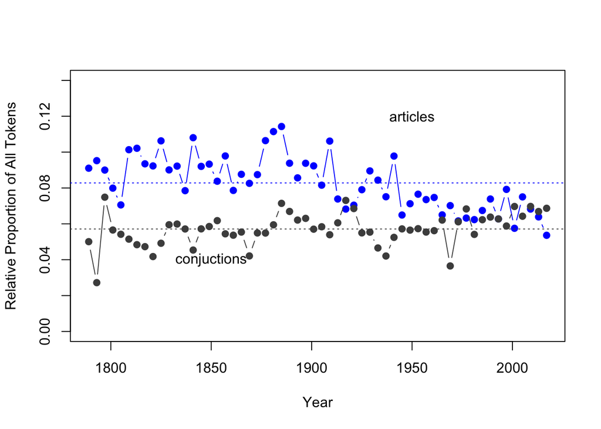

   Year <- as.integer(docvars(data_corpus_inaugural, "Year"))
   plot(Year, relativeDfm[, "ARTICLES"],
        ylim = c(0.0, 0.14),          # fix the range so that both sets fit
        pch = 19, col = "blue",  # blue solid points
        type = "b",
        ylab = "Relative Proportion of All Tokens")
   text(1950, .12, "articles")
   points(Year, relativeDfm[, "CONJUNCTIONS"], pch = 19, col = "grey30", type = "b")
   text(1850, .04, "conjuctions")
   abline(h = colMeans(relativeDfm[, c("ARTICLES", "CONJUNCTIONS")]), col = c("blue", "grey30"), lty = "dotted")
   ```

4. Keyword analysis
   1. After aggregating by party for all US presidents since 1960, perform a keyword analysis to identity the top 10 Democrat and top 10 Republican keywords.

```r
data("data_corpus_sotu", package = "quanteda.corpora")
str(data_corpus_sotu)
```

```
## List of 4
##  $ documents:'data.frame':   239 obs. of  8 variables:
##   ..$ texts    : chr [1:239] "Fellow-Citizens of the Senate and House of Representatives:\n\nI embrace with great satisfaction the opportunit"| __truncated__ "Fellow-Citizens of the Senate and House of Representatives:\n\nIn meeting you again I feel much satisfaction in"| __truncated__ "Fellow-Ci…
##   ..$ FirstName: chr [1:239] "George" "George" "George" "George" ...
##   ..$ President: chr [1:239] "Washington" "Washington" "Washington" "Washington" ...
##   ..$ Date     : Date[1:239], format: "1790-01-08" ...
##   ..$ delivery : Factor w/ 2 levels "spoken","written": 1 1 1 1 1 1 1 1 1 1 ...
##   ..$ type     : Factor w/ 2 levels "other","SOTU": 2 2 2 2 2 2 2 2 2 2 ...
##   ..$ party    : Factor w/ 6 levels "Democratic","Democratic-Republican",..: 4 4 4 4 4 4 4 4 3 3 ...
##   ..$ _document: chr [1:239] "Washington-1790" "Washington-1790b" "Washington-1791" "Washington-1792" ...
##  $ metadata :List of 2
##   ..$ source : chr "http://www.presidency.ucsb.edu/sou.php"
##   ..$ created: chr "Wed Apr  4 12:15:15 2018"
##  $ settings :List of 12
##   ..$ stopwords          : NULL
##   ..$ collocations       : NULL
##   ..$ dictionary         : NULL
##   ..$ valuetype          : chr "glob"
##   ..$ stem               : logi FALSE
##   ..$ delimiter_word     : chr " "
##   ..$ delimiter_sentence : chr ".!?"
##   ..$ delimiter_paragraph: chr "\n\n"
##   ..$ clean_tolower      : logi TRUE
##   ..$ clean_remove_digits: logi TRUE
##   ..$ clean_remove_punct : logi TRUE
##   ..$ units              : chr "documents"
##   ..- attr(*, "class")= chr [1:2] "settings" "list"
##  $ tokens   : NULL
```

```r
docvars(data_corpus_sotu, "year") <- as.numeric(format(docvars(data_corpus_sotu, "Date"), "%Y"))

sotu_1960 <- corpus_subset(data_corpus_sotu, year >= 1960)

sotu_dfm <- dfm(sotu_1960, groups = "party", remove_punct = TRUE, remove_numbers = TRUE, remove = stopwords("english"))

sotu_dfm[, 1:10]
```

```
## Document-feature matrix of: 6 documents, 10 features (68.3% sparse).
## 6 x 10 sparse Matrix of class "dfm"
##                        features
## docs                    mr president speaker members 86th congress seven
##   Democratic            63       199      41     108    0      931    16
##   Democratic-Republican  0         0       0       0    0        0     0
##   Federalist             0         0       0       0    0        0     0
##   Independent            0         0       0       0    0        0     0
##   Republican            69       163      55     106    1      537    14
##   Whig                   0         0       0       0    0        0     0
##                        features
## docs                    years ago entered
##   Democratic              726 127       7
##   Democratic-Republican     0   0       0
##   Federalist                0   0       0
##   Independent               0   0       0
##   Republican              512 154      10
##   Whig                      0   0       0
```

```r
?textstat_keyness
twoparty_key <- textstat_keyness(sotu_dfm, target = "Democratic")
head(twoparty_key)
```

```
##          feature     chi2            p n_target n_reference
## 1 administration 70.77889 0.000000e+00      462         147
## 2            u.s 45.26356 1.722245e-11      127          20
## 3        college 43.50925 4.219602e-11      132          23
## 4          solar 42.89957 5.762324e-11       73           3
## 5             fy 40.80096 1.685503e-10       59           0
## 6     regulatory 38.74950 4.818335e-10      103          15
```

```
b) Plot this using a keyness plot.
```

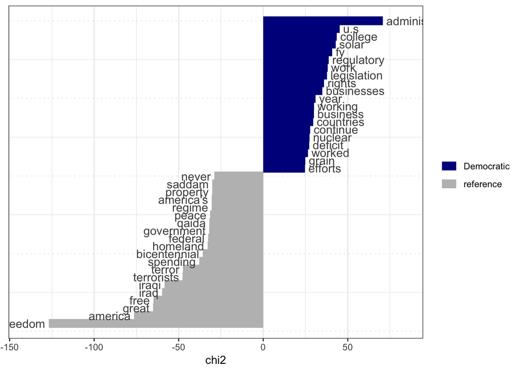

```
**Hint: See the examples from `?textplot_keyness`.
```

```r
textplot_keyness(twoparty_key)
```

5. Network analysis

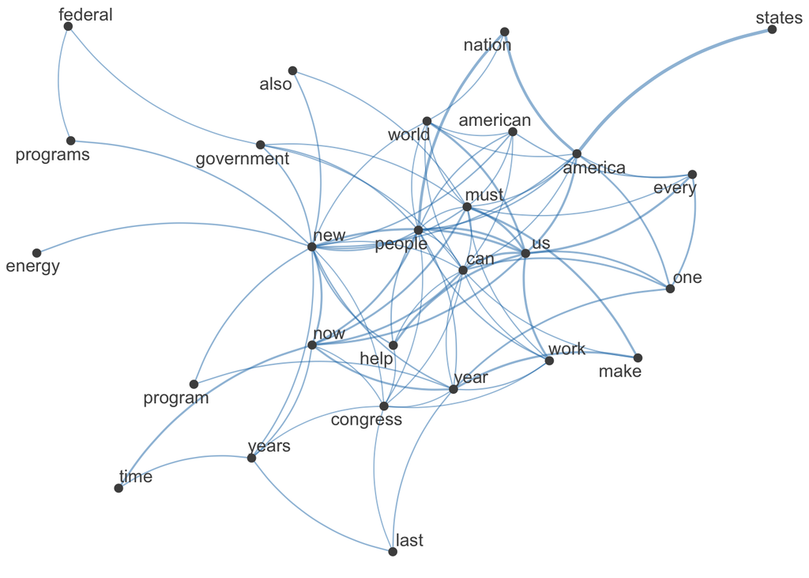

```r
toks <- sotu_1960 %>%
  tokens(remove_punct = TRUE) %>%
  tokens_tolower() %>%
  tokens_remove(stopwords("english"), padding = FALSE)
myfcm <- fcm(toks, context = "window", tri = FALSE)
feat <- names(topfeatures(myfcm, 30))
fcm_select(myfcm, feat, verbose = FALSE) %>%
  textplot_network(min_freq = 0.8)
```